# 18 - Biodiversity analysis

Francisco E. Fonturbel

21/February/2023

## Using R to conduct biodiversity analysis

Today we will learn how to analyze and make sense of our biodiversity data (after long campaigns in the field collecting data… really exhausting). The `BiodiversityR` package contains many useful functions to run biodiversity analysis (the first time that you load this package may be asked to install XQuartz).

```r
#Loading required packages
library(dplyr)
library(ggplot2)
library(ggsci)
library(ggpubr)
library(vegan)
library(BiodiversityR)
library(Rarefy)

#Loading work data
data = read.csv("data/18_canola.csv",
                   header=TRUE,
                   sep=",")

attach(data)

animal.dt<-data[,5:26]
env.dt<-data[,3:4]

env.dt$posicion<-as.factor(env.dt$posicion)
env.dt$color<-as.factor(env.dt$color)
```

Today we will use some data of [Jaques et al. 2023](https://www.mdpi.com/2073-4395/13/2/552) as a working example. This dataset contains data of insect pollinator in a canola crop (the one with the yellow flowers), comparing pan trap color and position effects in the diversity of insects captured.

## Rarefaction curves

How well sampled was our crop? To answer this question we may represent the cumulative number of species in function of the number of samples (pan traps) analyzed:

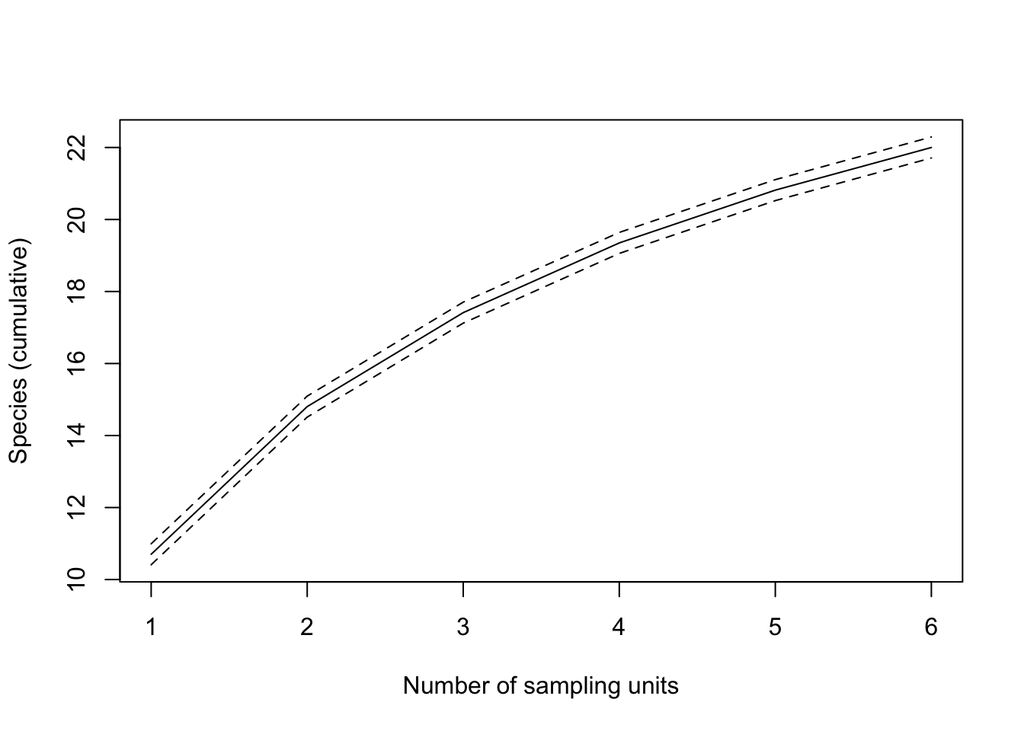

```r
raref_bb<-rare_alpha(animal.dt, method="hill", random=999, fun_div='speciesdiv', args=a, mean=TRUE)

plot(raref_bb[,1],ylab="Species (cumulative)",xlab="Number of sampling units",type="l", ylim=range(raref_bb,na.rm=TRUE))
lines(raref_bb[,2],lty=2)
lines(raref_bb[,3],lty=2)
```

When we open our first flask, all insects in there are new because we are starting from zero species. Then, we open the second flask we found many new species but some are repeated from the first flask. And if we continue to adding sampling units, the number of new species found decreases. When the rarefaction curve gets **asymptotic** (i.e., no now species are found despite adding more sampling units) we can say that our sampling was complete. In this case, of course, we were unable to capture the whole insect diversity at the canola crop.

So, how can we know how many species are “missing”? Fortunately, many people devoted a lot of time to answer this questions two decades ago and we have many indices of expected species richness, for example:

```r
animal.dt<-data[,5:26]
estimateR(animal.dt)
```

```
##               [,1]      [,2]      [,3]      [,4]      [,5]      [,6]
## S.obs    10.000000 13.000000 19.000000  8.000000  7.000000  8.000000
## S.chao1  11.000000 14.000000 55.000000  9.000000 10.000000 18.000000
## se.chao1  2.266355  1.804426 25.620837  1.796774  4.107919 10.127657
## S.ACE    11.017544 16.776786 30.986021 10.571429 18.012346 18.719955
## se.ACE    1.507958  2.024594  2.513306  1.524080  2.182228  2.463115
```

```r
specpool(animal.dt)
```

```
##     Species     chao  chao.se    jack1 jack1.se    jack2     boot  boot.se n
## All      22 27.10417 5.148247 27.83333 3.855011 30.36667 24.75937 2.568128 6
```

## Rank-abundance curves

Within biological communities is quite common to found very abundant species (the dominant ones) and others that are present in low abundances (also known as rare species). If we have quantitative data, we can estimate a relative abundance of those species and order them from the most abundant to the least:

```r
rab.pol<-rankabundance(animal.dt)
rab.pol
```

```
##                            rank abundance proportion plower pupper accumfreq
## Alloscirtetica.tristrigata    1       128       26.5    1.7   51.3      26.5
## Corynura.chloris              2       117       24.2    8.2   40.2      50.7
## Lasioglossum.sp1              3        65       13.5    5.9   21.0      64.2
## Ruizantheda.proxima           4        40        8.3    3.4   13.2      72.5
## Apis.mellifera                5        31        6.4   -0.8   13.6      78.9
## Astylus.trifasciatus          6        26        5.4    1.4    9.4      84.3
## Lasioglossum.sp2              7        18        3.7   -1.7    9.2      88.0
## Manuelia.gayatina             8        15        3.1    2.0    4.2      91.1
## Arthrobrachus.sp1             9        12        2.5   -0.8    5.8      93.6
## Chrysomelidae.sp1            10         8        1.7    0.4    2.9      95.2
## Eristalis.tenax              11         5        1.0   -1.0    3.1      96.3
## Toxomerus.vertebratus        12         4        0.8   -0.3    1.9      97.1
## Sphecodes.sp1                13         3        0.6   -0.1    1.3      97.7
## Plastonotus.sp               14         2        0.4   -0.2    1.0      98.1
## Platycheirus.punctulata      15         2        0.4   -0.3    1.2      98.6
## Halictillus.verissimus       16         1        0.2   -0.3    0.7      98.8
## Hylodanacaea.atrocaerulea    17         1        0.2   -0.3    0.7      99.0
## Lasioglossum.sp3             18         1        0.2   -0.3    0.7      99.2
## Lepidoptera.sp3              19         1        0.2   -0.3    0.7      99.4
## Lithraeus.sp1                20         1        0.2   -0.3    0.7      99.6
## Manuelia.postica             21         1        0.2   -0.4    0.8      99.8
## Ruizantheda.mutabilis        22         1        0.2   -0.3    0.7     100.0
##                            logabun rankfreq
## Alloscirtetica.tristrigata     2.1      4.5
## Corynura.chloris               2.1      9.1
## Lasioglossum.sp1               1.8     13.6
## Ruizantheda.proxima            1.6     18.2
## Apis.mellifera                 1.5     22.7
## Astylus.trifasciatus           1.4     27.3
## Lasioglossum.sp2               1.3     31.8
## Manuelia.gayatina              1.2     36.4
## Arthrobrachus.sp1              1.1     40.9
## Chrysomelidae.sp1              0.9     45.5
## Eristalis.tenax                0.7     50.0
## Toxomerus.vertebratus          0.6     54.5
## Sphecodes.sp1                  0.5     59.1
## Plastonotus.sp                 0.3     63.6
## Platycheirus.punctulata        0.3     68.2
## Halictillus.verissimus         0.0     72.7
## Hylodanacaea.atrocaerulea      0.0     77.3
## Lasioglossum.sp3               0.0     81.8
## Lepidoptera.sp3                0.0     86.4
## Lithraeus.sp1                  0.0     90.9
## Manuelia.postica               0.0     95.5
## Ruizantheda.mutabilis          0.0    100.0
```

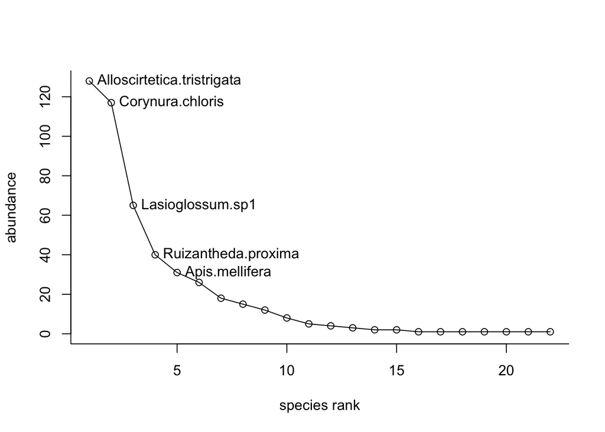

```r
rankabunplot(rab.pol, scale='abundance')
```

As we can see, there are some abundant species that dominate the community, and many others that occur in low abundances.

Let’s compare this between pan traps placed at the border or the center of the crop:

**Border**

```r
rab.bor<-rankabundance(animal.dt, y=env.dt, factor="posicion", level="border")
rab.bor
```

```
##                            rank abundance proportion plower pupper accumfreq
## Alloscirtetica.tristrigata    1        97       26.1  -29.6   81.8      26.1
## Corynura.chloris              2        67       18.0   -2.9   38.9      44.1
## Lasioglossum.sp1              3        65       17.5   14.4   20.6      61.6
## Ruizantheda.proxima           4        35        9.4   -0.3   19.1      71.0
## Astylus.trifasciatus          5        22        5.9   -3.7   15.5      76.9
## Apis.mellifera                6        20        5.4  -10.4   21.2      82.3
## Lasioglossum.sp2              7        18        4.8   -7.5   17.1      87.1
## Manuelia.gayatina             8        12        3.2    0.9    5.6      90.3
## Arthrobrachus.sp1             9        11        3.0   -4.9   10.8      93.3
## Chrysomelidae.sp1            10         7        1.9   -0.6    4.4      95.2
## Eristalis.tenax              11         4        1.1   -3.8    5.9      96.2
## Toxomerus.vertebratus        12         3        0.8   -1.4    3.0      97.0
## Plastonotus.sp               13         2        0.5   -0.8    1.9      97.6
## Sphecodes.sp1                14         2        0.5   -0.8    1.9      98.1
## Halictillus.verissimus       15         1        0.3   -0.9    1.5      98.4
## Hylodanacaea.atrocaerulea    16         1        0.3   -0.8    1.3      98.7
## Lasioglossum.sp3             17         1        0.3   -0.9    1.5      98.9
## Lepidoptera.sp3              18         1        0.3   -0.9    1.5      99.2
## Lithraeus.sp1                19         1        0.3   -0.9    1.5      99.5
## Platycheirus.punctulata      20         1        0.3   -0.9    1.5      99.7
## Ruizantheda.mutabilis        21         1        0.3   -0.9    1.5     100.0
##                            logabun rankfreq
## Alloscirtetica.tristrigata     2.0      4.8
## Corynura.chloris               1.8      9.5
## Lasioglossum.sp1               1.8     14.3
## Ruizantheda.proxima            1.5     19.0
## Astylus.trifasciatus           1.3     23.8
## Apis.mellifera                 1.3     28.6
## Lasioglossum.sp2               1.3     33.3
## Manuelia.gayatina              1.1     38.1
## Arthrobrachus.sp1              1.0     42.9
## Chrysomelidae.sp1              0.8     47.6
## Eristalis.tenax                0.6     52.4
## Toxomerus.vertebratus          0.5     57.1
## Plastonotus.sp                 0.3     61.9
## Sphecodes.sp1                  0.3     66.7
## Halictillus.verissimus         0.0     71.4
## Hylodanacaea.atrocaerulea      0.0     76.2
## Lasioglossum.sp3               0.0     81.0
## Lepidoptera.sp3                0.0     85.7
## Lithraeus.sp1                  0.0     90.5
## Platycheirus.punctulata        0.0     95.2
## Ruizantheda.mutabilis          0.0    100.0
```

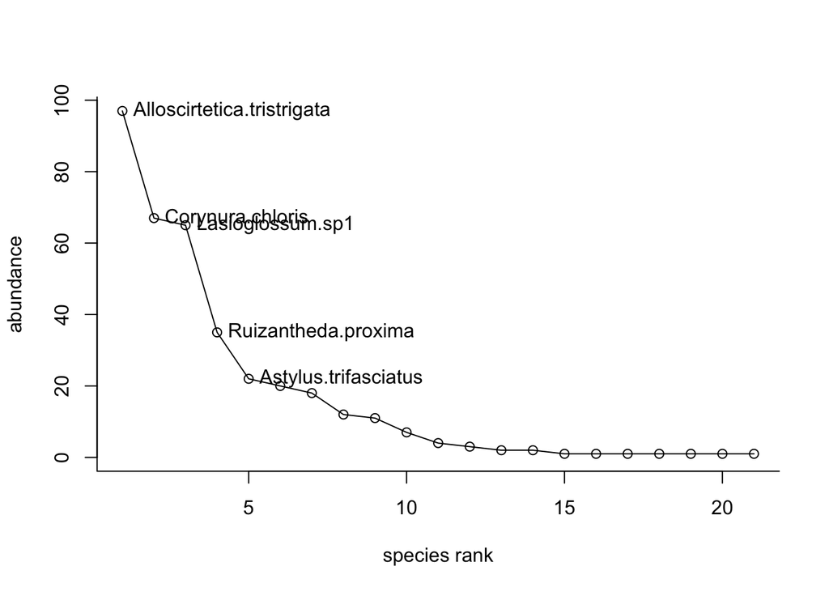

```r
rankabunplot(rab.bor, scale='abundance')
```

**Center**

```r
rab.cen<-rankabundance(animal.dt, y=env.dt, factor="posicion", level="center")
rab.cen
```

```
##                            rank abundance proportion plower pupper accumfreq
## Corynura.chloris              1        50       45.0  -13.5  103.6      45.0
## Alloscirtetica.tristrigata    2        31       27.9  -49.3  105.1      73.0
## Apis.mellifera                3        11        9.9   -8.3   28.1      82.9
## Ruizantheda.proxima           4         5        4.5   -8.9   17.9      87.4
## Astylus.trifasciatus          5         4        3.6   -0.6    7.8      91.0
## Manuelia.gayatina             6         3        2.7   -0.3    5.7      93.7
## Arthrobrachus.sp1             7         1        0.9   -2.3    4.1      94.6
## Chrysomelidae.sp1             8         1        0.9   -2.9    4.8      95.5
## Eristalis.tenax               9         1        0.9   -3.9    5.7      96.4
## Manuelia.postica             10         1        0.9   -3.9    5.7      97.3
## Platycheirus.punctulata      11         1        0.9   -2.9    4.8      98.2
## Sphecodes.sp1                12         1        0.9   -2.3    4.1      99.1
## Toxomerus.vertebratus        13         1        0.9   -3.9    5.7     100.0
##                            logabun rankfreq
## Corynura.chloris               1.7      7.7
## Alloscirtetica.tristrigata     1.5     15.4
## Apis.mellifera                 1.0     23.1
## Ruizantheda.proxima            0.7     30.8
## Astylus.trifasciatus           0.6     38.5
## Manuelia.gayatina              0.5     46.2
## Arthrobrachus.sp1              0.0     53.8
## Chrysomelidae.sp1              0.0     61.5
## Eristalis.tenax                0.0     69.2
## Manuelia.postica               0.0     76.9
## Platycheirus.punctulata        0.0     84.6
## Sphecodes.sp1                  0.0     92.3
## Toxomerus.vertebratus          0.0    100.0
```

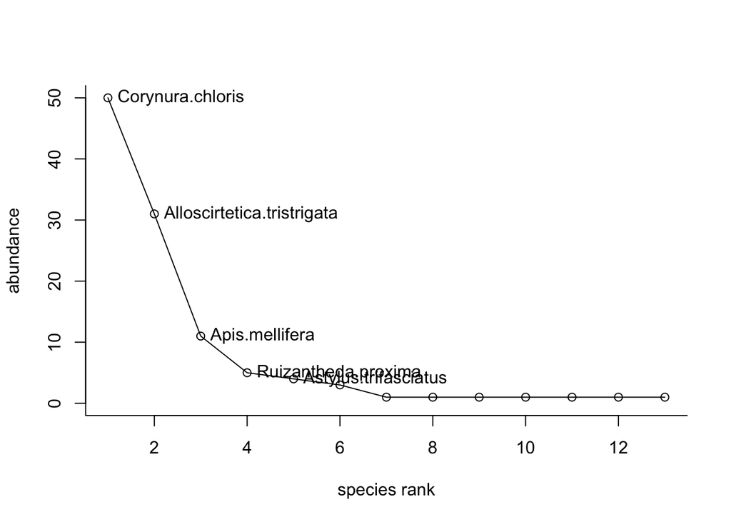

```r
rankabunplot(rab.cen, scale='abundance')
```

We can observe that different insect species dominate in the crop’s border or the center.

And now let’s compare insect diversity by pan-trap color:

**White**

```r
rab.w<-rankabundance(animal.dt, y=env.dt, factor="color", level="white")
rab.w
```

```
##                            rank abundance proportion plower pupper accumfreq
## Corynura.chloris              1        51       32.5 -194.2  259.2      32.5
## Apis.mellifera                2        22       14.0   -8.6   36.6      46.5
## Lasioglossum.sp1              3        21       13.4  -73.2  100.0      59.9
## Ruizantheda.proxima           4        16       10.2  -55.8   76.2      70.1
## Astylus.trifasciatus          5        14        8.9  -16.4   34.3      79.0
## Alloscirtetica.tristrigata    6        13        8.3  -29.1   45.7      87.3
## Arthrobrachus.sp1             7         7        4.5  -24.4   33.3      91.7
## Manuelia.gayatina             8         4        2.5    2.2    2.9      94.3
## Chrysomelidae.sp1             9         3        1.9   -1.9    5.7      96.2
## Toxomerus.vertebratus        10         2        1.3   -7.0    9.5      97.5
## Lasioglossum.sp3             11         1        0.6   -3.5    4.8      98.1
## Plastonotus.sp               12         1        0.6   -3.5    4.8      98.7
## Platycheirus.punctulata      13         1        0.6  -11.4   12.7      99.4
## Sphecodes.sp1                14         1        0.6   -3.5    4.8     100.0
##                            logabun rankfreq
## Corynura.chloris               1.7      7.1
## Apis.mellifera                 1.3     14.3
## Lasioglossum.sp1               1.3     21.4
## Ruizantheda.proxima            1.2     28.6
## Astylus.trifasciatus           1.1     35.7
## Alloscirtetica.tristrigata     1.1     42.9
## Arthrobrachus.sp1              0.8     50.0
## Manuelia.gayatina              0.6     57.1
## Chrysomelidae.sp1              0.5     64.3
## Toxomerus.vertebratus          0.3     71.4
## Lasioglossum.sp3               0.0     78.6
## Plastonotus.sp                 0.0     85.7
## Platycheirus.punctulata        0.0     92.9
## Sphecodes.sp1                  0.0    100.0
```

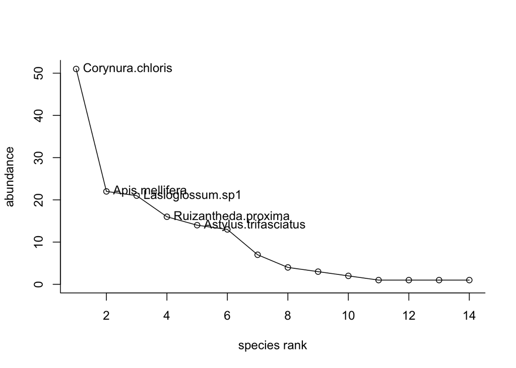

```r
rankabunplot(rab.w, scale='abundance')
```

**Yellow**

```r
rab.y<-rankabundance(animal.dt, y=env.dt, factor="color", level="yellow")
rab.y
```

```
##                            rank abundance proportion plower pupper accumfreq
## Corynura.chloris              1        37       28.0  -23.5   79.5      28.0
## Alloscirtetica.tristrigata    2        19       14.4    9.3   19.5      42.4
## Lasioglossum.sp1              3        18       13.6  -36.2   63.5      56.1
## Lasioglossum.sp2              4        12        9.1  -24.2   42.3      65.2
## Ruizantheda.proxima           5         9        6.8  -26.0   39.6      72.0
## Astylus.trifasciatus          6         6        4.5  -12.1   21.2      76.5
## Manuelia.gayatina             7         6        4.5    1.9    7.2      81.1
## Apis.mellifera                8         5        3.8   -1.6    9.2      84.8
## Eristalis.tenax               9         5        3.8   -1.6    9.2      88.6
## Arthrobrachus.sp1            10         4        3.0   -8.1   14.1      91.7
## Toxomerus.vertebratus        11         2        1.5  -12.2   15.2      93.2
## Chrysomelidae.sp1            12         1        0.8   -2.0    3.5      93.9
## Halictillus.verissimus       13         1        0.8   -2.0    3.5      94.7
## Lepidoptera.sp3              14         1        0.8   -2.0    3.5      95.5
## Lithraeus.sp1                15         1        0.8   -2.0    3.5      96.2
## Manuelia.postica             16         1        0.8  -15.7   17.2      97.0
## Plastonotus.sp               17         1        0.8   -2.0    3.5      97.7
## Platycheirus.punctulata      18         1        0.8   -2.0    3.5      98.5
## Ruizantheda.mutabilis        19         1        0.8   -2.0    3.5      99.2
## Sphecodes.sp1                20         1        0.8   -2.0    3.5     100.0
##                            logabun rankfreq
## Corynura.chloris               1.6        5
## Alloscirtetica.tristrigata     1.3       10
## Lasioglossum.sp1               1.3       15
## Lasioglossum.sp2               1.1       20
## Ruizantheda.proxima            1.0       25
## Astylus.trifasciatus           0.8       30
## Manuelia.gayatina              0.8       35
## Apis.mellifera                 0.7       40
## Eristalis.tenax                0.7       45
## Arthrobrachus.sp1              0.6       50
## Toxomerus.vertebratus          0.3       55
## Chrysomelidae.sp1              0.0       60
## Halictillus.verissimus         0.0       65
## Lepidoptera.sp3                0.0       70
## Lithraeus.sp1                  0.0       75
## Manuelia.postica               0.0       80
## Plastonotus.sp                 0.0       85
## Platycheirus.punctulata        0.0       90
## Ruizantheda.mutabilis          0.0       95
## Sphecodes.sp1                  0.0      100
```

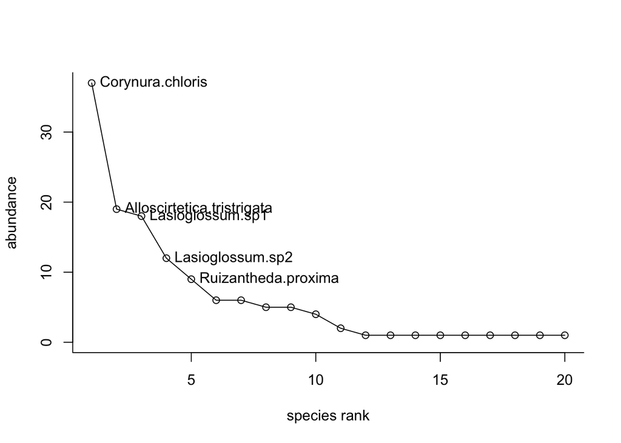

```r
rankabunplot(rab.y, scale='abundance')
```

**Blue**

```r
rab.b<-rankabundance(animal.dt, y=env.dt, factor="color", level="blue")
rab.b
```

```
##                            rank abundance proportion plower pupper accumfreq
## Alloscirtetica.tristrigata    1        96       49.5   32.9   66.1      49.5
## Corynura.chloris              2        29       14.9  -79.7  109.6      64.4
## Lasioglossum.sp1              3        26       13.4  -77.9  104.7      77.8
## Ruizantheda.proxima           4        15        7.7  -18.7   34.2      85.6
## Astylus.trifasciatus          5         6        3.1   -2.0    8.2      88.7
## Lasioglossum.sp2              6         6        3.1  -18.0   24.2      91.8
## Manuelia.gayatina             7         5        2.6   -1.9    7.0      94.3
## Apis.mellifera                8         4        2.1  -23.2   27.3      96.4
## Chrysomelidae.sp1             9         4        2.1  -12.0   16.1      98.5
## Arthrobrachus.sp1            10         1        0.5   -9.1   10.1      99.0
## Hylodanacaea.atrocaerulea    11         1        0.5   -3.0    4.0      99.5
## Sphecodes.sp1                12         1        0.5   -9.1   10.1     100.0
##                            logabun rankfreq
## Alloscirtetica.tristrigata     2.0      8.3
## Corynura.chloris               1.5     16.7
## Lasioglossum.sp1               1.4     25.0
## Ruizantheda.proxima            1.2     33.3
## Astylus.trifasciatus           0.8     41.7
## Lasioglossum.sp2               0.8     50.0
## Manuelia.gayatina              0.7     58.3
## Apis.mellifera                 0.6     66.7
## Chrysomelidae.sp1              0.6     75.0
## Arthrobrachus.sp1              0.0     83.3
## Hylodanacaea.atrocaerulea      0.0     91.7
## Sphecodes.sp1                  0.0    100.0
```

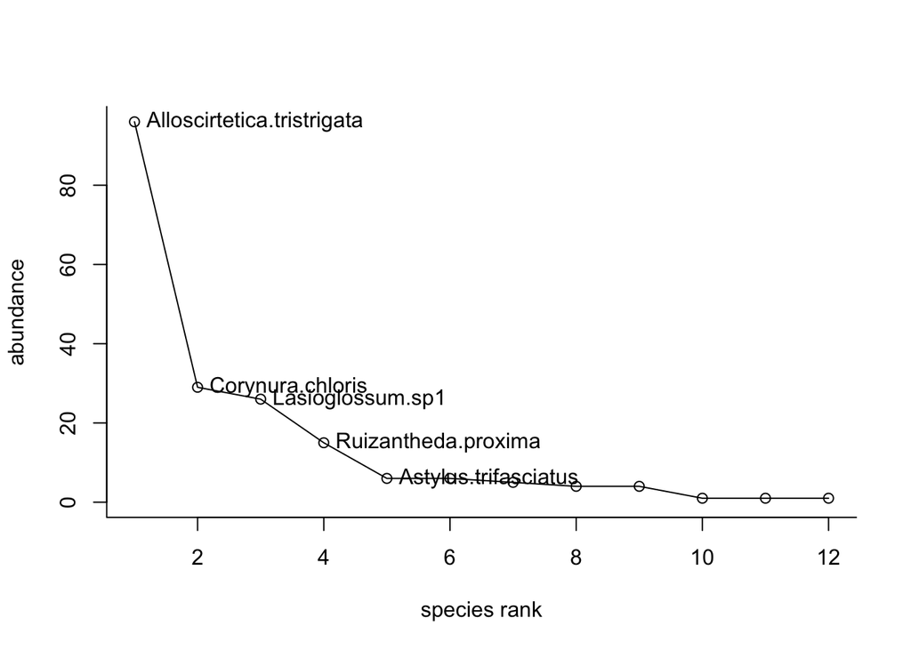

```r
rankabunplot(rab.b, scale='abundance')
```

Impressive! there are huge differences in dominance. We may go back to lesson 16 and apply an ANOSIM test to this data (or simply read Solange’s paper in full).

## Species diversity

```r
#Spp richness
div_s<-diversityresult(animal.dt, y=NULL, index="richness", method="pooled", digits=3)

##By trap location
div_sb<-diversityresult(animal.dt, y=env.dt, factor="posicion", level="border", index="richness", method="pooled", sortit=TRUE, digits=3)
div_sc<-diversityresult(animal.dt, y=env.dt, factor="posicion", level="center", index="richness", method="pooled", sortit=TRUE, digits=3)

##By colors
div_sw<-diversityresult(animal.dt, y=env.dt, factor="color", level="white", index="richness", method="pooled", sortit=TRUE, digits=3)
div_sy<-diversityresult(animal.dt, y=env.dt, factor="color", level="yellow", index="richness", method="pooled", sortit=TRUE, digits=3)
div_sb<-diversityresult(animal.dt, y=env.dt, factor="color", level="blue", index="richness", method="pooled", sortit=TRUE, digits=3)

#Overall diversity
div_all<-diversityresult(animal.dt, y=NULL, index="Shannon", method="mean", digits=3)

##By trap location
div_border<-diversityresult(animal.dt, y=env.dt, factor="posicion", level="border", index="Shannon", method="mean", sortit=TRUE, digits=3)
div_center<-diversityresult(animal.dt, y=env.dt, factor="posicion", level="center", index="Shannon", method="mean", sortit=TRUE, digits=3)

##By colors
div_w<-diversityresult(animal.dt, y=env.dt, factor="color", level="white", index="Shannon", method="mean", sortit=TRUE, digits=3)
div_y<-diversityresult(animal.dt, y=env.dt, factor="color", level="yellow", index="Shannon", method="mean", sortit=TRUE, digits=3)
div_b<-diversityresult(animal.dt, y=env.dt, factor="color", level="blue", index="Shannon", method="mean", sortit=TRUE, digits=3)

#Evenness
div_ev<-diversityresult(animal.dt, y=NULL, index="Eevenness", method="mean", digits=3)

##By trap location
div_eb<-diversityresult(animal.dt, y=env.dt, factor="posicion", level="border", index="Eevenness", method="mean", sortit=TRUE, digits=3)
div_ec<-diversityresult(animal.dt, y=env.dt, factor="posicion", level="center", index="Eevenness", method="mean", sortit=TRUE, digits=3)

##By colors
div_ew<-diversityresult(animal.dt, y=env.dt, factor="color", level="white", index="Eevenness", method="mean", sortit=TRUE, digits=3)
div_ey<-diversityresult(animal.dt, y=env.dt, factor="color", level="yellow", index="Eevenness", method="mean", sortit=TRUE, digits=3)
div_eb<-diversityresult(animal.dt, y=env.dt, factor="color", level="blue", index="Eevenness", method="mean", sortit=TRUE, digits=3)
```

#### Species richness

[output not shown]

#### Diversity

| Comparison | H’ |
| --- | --- |
| Overall | 1.711 |
| Border | 2.037 |
| Center | 1.384 |
| White | 1.624 |
| Yellow | 2.03 |
| Blue | 1.478 |

#### Evenness

[output not shown]

While we can calculate this by hand, with a pencil, a piece of papers, and a simple calculator (as I did 20 years ago when was an undergraduate student), this procedure simplifies such calculations, particularly when we have too many species.

## Final thoughts

Biodiversity analysis in R is simple and straightforward. Here I presented only a few options, but I highly encourage you to explore the `BiodiversityR` package a little bit further on your own.

Licensing Creative Commons License

Licensed under a Creative Commons Attribution-ShareAlike 4.0 International License.  
2022 - Francisco E. Fontúrbel